# Reproducible online supplementary material

## 2.1 Accounting for ordinal outcomes in the project funding evaluation

Similar results are found when using a Bayesian hierarchical model that explicitly accounts for the ordinal nature of the scores, see Figure 2.5. Figure 2.6 shows the Bland-Altman plot; the agreement between the BR with an ordinal outcome model and the BR with a continuous outcome model. The mean of all the differences (gray horizontal line) is very close to 0. The differences in ER for most proposals lie in the 95% limits of agreement (red dotted horizontal lines). However, even though both models result in similar results, it is hard to say which modelling approach performs better without knowing exactly which proposals should have been funded or rejected.}

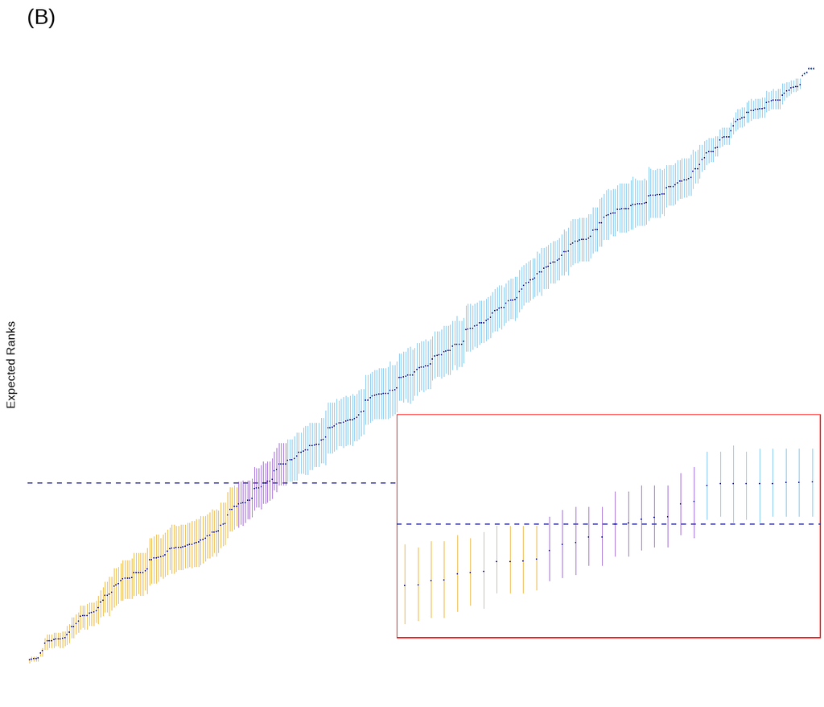

Figure 2.5: The ER - computed using an ordinal outcome model - ordered from the best (rank 1) to the worst (rank 352) together with their 50% credible intervals. A naive funding line to ensure a 30% success rate is drawn (blue dashed line).

```r
plot_er_cred_mint_ordinal <-
  plot_er_distributions(get_mcmc_samples_result = mcmc_mint_ordinal,
                        n_proposals = mint_sections %>%
                          summarise(n_distinct(proposal)) %>% pull(),
                        name_er_or_theta = "rank_theta", title = "(B)",
                        names_proposals = mint_sections %>%
                          pull(proposal) %>% unique(),
                        number_fundable = x,
                        size_pt = .1, size_outer = 0, size_inner = .3,
                        alpha_inner = .8, outer_show = FALSE) +
  theme(axis.text.x = element_blank(),
        panel.grid.major.x = element_blank(),
        axis.title.y = element_text(size = 7, vjust = 2))

p.zoomrast_ordinal <- plot_er_cred_mint_ordinal +
  xlim(levels(plot_er_cred_mint_ordinal$data$parameter)[90:121]) +
  ylim(c(74, 140)) +
  zoomtheme

plot_er_cred_mint_ordinal +
  theme(legend.position = "none") +
  annotation_custom(grob = ggplotGrob(p.zoomrast),
                    xmin = 160, xmax = 360,
                    ymin = min(ranks_mint$rankings$er) + 5,
                    ymax = min(ranks_mint$rankings$er) + 150)
```

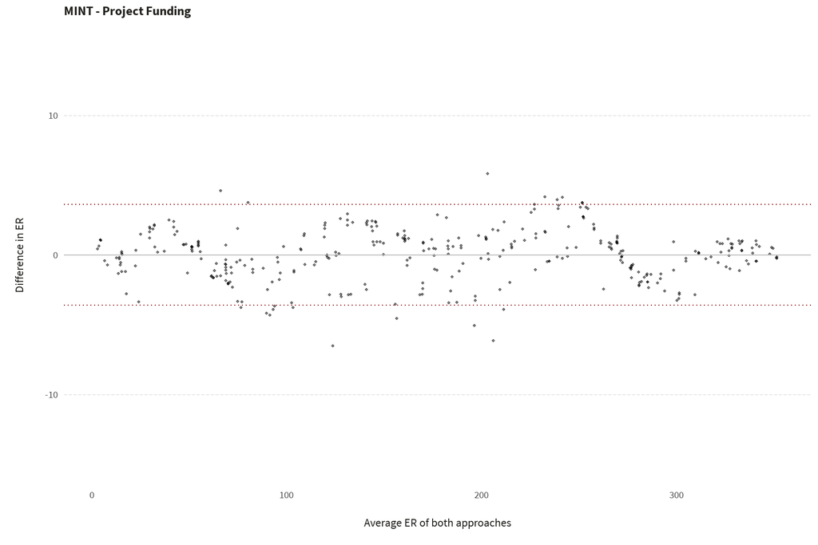

Figure 2.6: Difference in expected rank depending on whether the outcome is modeled as continuous or ordinal variable versus the average ER as computed using the continuous and ordinal outcome model, for all proposals evaluated for project funding. The 95% limits of agreement are plotted (red dotted lines) as well as the mean difference (gray line, bias).

```r
get_agreement_plot(ranks_mint$rankings,
                   ranks_mint_ordinal$rankings,
                   title = "MINT - Project Funding",
                   ymin = -15, ymax = 15, pt_alpha = .5,
                   pt_size = .8)
```

# 3 Note on convergence diagnostics

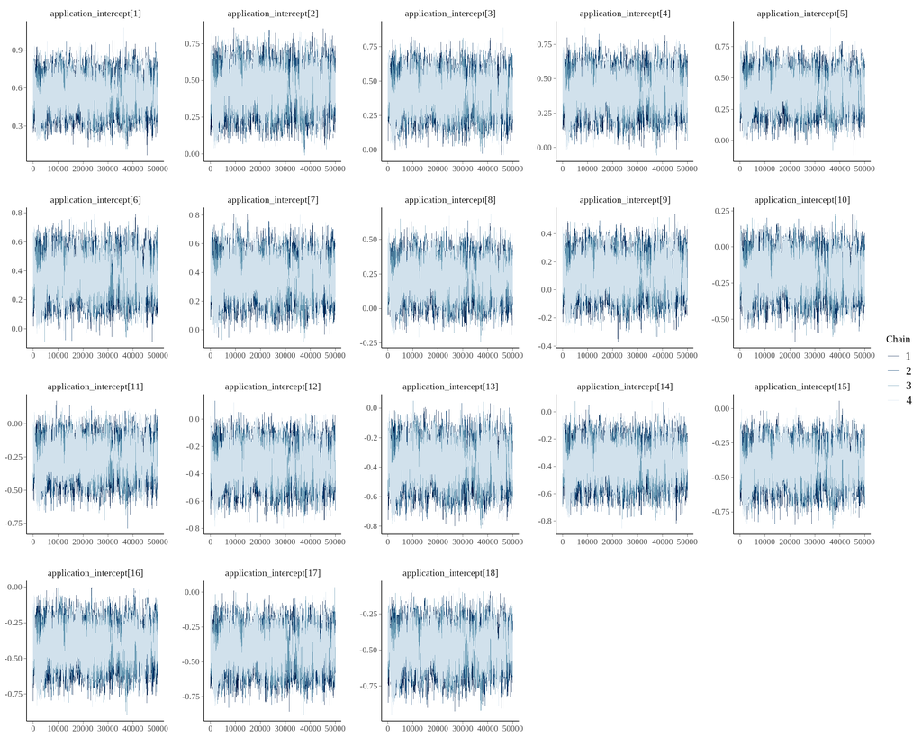

Figure 3.1: Traceplots of the proposal effects of all 18 proposals in the Biology panel for the Postdoc.Mobility fellowships.

```r
bayesplot::mcmc_trace(mcmc_ls_b_object$samples,
                      pars = paste0("application_intercept[", 1:18, "]"))
```

Below we show the values *R̂* of the Gelman-Rubin convergence diagnostic and traceplots for some important parameters for the Social Sciences panel in the Postdoc.Mobility case study. *R̂* values substantially above 1 indicate lack of convergence. Gelman et al. (2014) have recommended to use $1.1$ as threshold value for *R̂*. The default in the `ERforResearch` package is even lower at $1.01$.

```r
## PM case study setting
n.iter <- 50 * 10^{3}
n.burnin <- 10 * 10^{3}
n.adapt <- 10 * 10^{3}
max.iter <- 50 * 10^{3}
n.chains <- 4
seed <- 1991
seed_ordinal <- seed + 1

## Ordinal models:
# refit the model without pooling the 2 chains
mcmc_hss_s_ordinal_2 <-
  get_mcmc_samples(data = hss_s,
                   id_application = "proposal",
                   id_voter = "voter",
                   grade_variable = "num_grade",
                   n_chains = n.chains, n_iter = n.iter,
                   n_burnin = n.burnin, n_adapt = n.adapt,
                   max_iter = max.iter,
                   ordinal_scale = TRUE, point_scale = 6,
                   seed = seed_ordinal, quiet = TRUE,
                   dont_bind = TRUE)
```

```
## [1] "Be aware that the default ordinal model fixes the outcome to a six-\n          point scale."
## [1] "Caution: Even after increasing the adaption phase to 10000 iterations, the burnin phase to 10000 and the number of iterations to 50000 the max of the Rhat values is 1.01 e.g. > 1.01. The problematic parameter(s) is (are): application_intercept[7], application_intercept[10], application_inter…
```

```r
# do not perform multivariate computation since this sometimes leads to
# error messages and we do not need that result
# use the whole series, not only the second half (autoburnin = FALSE)
rhat_hss_s <- gelman.diag(mcmc_hss_s_ordinal_2$samples, autoburnin = FALSE,
                          multivariate = FALSE)
# rhat_est_hss_s <- rhat_hss_s$psrf[ ,1]
```

```r
# create R_hat values table for Social Sciences panel in PM
n_proposal <- 18
n_voter <- 14
# adapt the row names to notation in the paper
rownames <- c(paste0("$\\theta_{", seq(1, n_proposal), "}$"),
              # paste0("$\\nu_{", seq(1, n_voter), "}$"),
              paste0("rank", "$(\\theta_{", seq(1, n_proposal), "})$"),
              "$\\sigma$", "$\\tau$", "$\\tau_{\\nu}$")

table_hss_s <- as.data.frame(cbind(rhat_hss_s$psrf[ ,1]))#, rhat_hss_s$psrf[ ,2]))
row.names(table_hss_s) <- rownames

kable(table_hss_s, digits = 2, escape = FALSE,
      col.names =  c("$\\widehat{R}$"),#, "Upper CI limit"),
      row.names = TRUE, booktabs = TRUE,
      longtable = TRUE,
      caption = "Estimates of $\\widehat{R}$, the Gelman-Rubin convergence diagnostic
      are given for different parameters in the ordinal model for the Social Sciences panel in the PM case study.") %>%
  #, and the upper limits of the 95\\% confidence intervals for $\\widehat{R}$
  kable_styling(latex_options = c("hold_position", "repeat_header"))
```

Table 3.1: Estimates of *R̂*, the Gelman-Rubin convergence diagnostic are given for different parameters in the ordinal model for the Social Sciences panel in the PM case study.

|  | *R̂* |
| --- | --- |
| *θ*<sub>1</sub> | 1.01 |
| *θ*<sub>2</sub> | 1.01 |
| *θ*<sub>3</sub> | 1.01 |
| *θ*<sub>4</sub> | 1.01 |
| *θ*<sub>5</sub> | 1.01 |
| *θ*<sub>6</sub> | 1.01 |
| *θ*<sub>7</sub> | 1.01 |
| *θ*<sub>8</sub> | 1.01 |
| *θ*<sub>9</sub> | 1.01 |
| *θ*<sub>10</sub> | 1.01 |
| *θ*<sub>11</sub> | 1.01 |
| *θ*<sub>12</sub> | 1.01 |
| *θ*<sub>13</sub> | 1.01 |
| *θ*<sub>14</sub> | 1.01 |
| *θ*<sub>15</sub> | 1.01 |
| *θ*<sub>16</sub> | 1.01 |
| *θ*<sub>17</sub> | 1.00 |
| *θ*<sub>18</sub> | 1.00 |
| rank(*θ*<sub>1</sub>) | 1.00 |
| rank(*θ*<sub>2</sub>) | 1.00 |
| rank(*θ*<sub>3</sub>) | 1.00 |
| rank(*θ*<sub>4</sub>) | 1.00 |
| rank(*θ*<sub>5</sub>) | 1.00 |
| rank(*θ*<sub>6</sub>) | 1.00 |
| rank(*θ*<sub>7</sub>) | 1.00 |
| rank(*θ*<sub>8</sub>) | 1.00 |
| rank(*θ*<sub>9</sub>) | 1.00 |
| rank(*θ*<sub>10</sub>) | 1.00 |
| rank(*θ*<sub>11</sub>) | 1.00 |
| rank(*θ*<sub>12</sub>) | 1.00 |
| rank(*θ*<sub>13</sub>) | 1.00 |
| rank(*θ*<sub>14</sub>) | 1.00 |
| rank(*θ*<sub>15</sub>) | 1.00 |
| rank(*θ*<sub>16</sub>) | 1.00 |
| rank(*θ*<sub>17</sub>) | 1.00 |
| rank(*θ*<sub>18</sub>) | 1.00 |
| *σ* | 1.00 |
| *τ* | 1.00 |
| *τ*<sub>*ν*</sub> | 1.00 |

# 4 Hyper-prior sensitivity

```r
## Use different JAGS model:
cat("model{
      # Likelihood:
      for (i in 1:n) { # i is not the application but the review
          grade[i] ~ dnorm(mu[i], inv_sigma2)
                # inv_sigma2 is precision (1 / variance)
          mu[i] <- overall_mean + application_intercept[num_application[i]] +
          voter_intercept[num_application[i], num_voter[i]]
      }
      # Ranks:
      rank_theta[1:n_application] <- rank(-application_intercept[])
      # Priors:
      for (j in 1:n_application){
        application_intercept[j] ~ dnorm(0, inv_tau_application2)
      }
      for (l in 1:n_voter){
        for(j in 1:n_application){
          voter_intercept[j, l] ~ dnorm(nu[l], inv_tau_voter2)
        }
      }
      for (l in 1:n_voter){
        nu[l] ~ dnorm(0, 100) # 1/(0.1^2) = 100
      }
      sigma ~ dunif(0.000001, 2)
      inv_sigma2 <- pow(sigma, -2)
      inv_tau_application2 <- pow(tau_application, -2)
      tau_application ~ dunif(0.000001, 2)
      inv_tau_voter2 <- pow(tau_voter, -2)
      tau_voter ~ dunif(0.000001, 2)
    }",
    file = here("minor_revision", "manuscript",
                "jags_model_change_nuvariance_smaller.txt"))

cat("model{
      # Likelihood:
      for (i in 1:n) { # i is not the application but the review
          grade[i] ~ dnorm(mu[i], inv_sigma2)
                # inv_sigma2 is precision (1 / variance)
          mu[i] <- overall_mean + application_intercept[num_application[i]] +
          voter_intercept[num_application[i], num_voter[i]]
      }
      # Ranks:
      rank_theta[1:n_application] <- rank(-application_intercept[])
      # Priors:
      for (j in 1:n_application){
        application_intercept[j] ~ dnorm(0, inv_tau_application2)
      }
      for (l in 1:n_voter){
        for(j in 1:n_application){
          voter_intercept[j, l] ~ dnorm(nu[l], inv_tau_voter2)
        }
      }
      for (l in 1:n_voter){
        nu[l] ~ dnorm(0, 0.25) # 1/(2^2) = 0.25
      }
      sigma ~ dunif(0.000001, 2)
      inv_sigma2 <- pow(sigma, -2)
      inv_tau_application2 <- pow(tau_application, -2)
      tau_application ~ dunif(0.000001, 2)
      inv_tau_voter2 <- pow(tau_voter, -2)
      tau_voter ~ dunif(0.000001, 2)
    }",
    file = here("minor_revision", "manuscript",
                "jags_model_change_nuvariance_larger.txt"))

##### Get the ER results: ####
n.iter <- 50 * 10^{3}
n.burnin <- 10 * 10^{3}
n.adapt <- 10 * 10^{3}
max.iter <- 50 * 10^{3}
n.chains <- 4
seed <- 1991


mcmc_hss_s_object_smaller_variance <-
  get_mcmc_samples(data = hss_s,
                   id_application = "proposal",
                   id_voter = "voter",
                   grade_variable = "num_grade",
                   path_to_jags_model =
                     here("minor_revision", "manuscript",
                          "jags_model_change_nuvariance_smaller.txt"),
                   n_chains = n.chains, n_iter = n.iter,
                   n_burnin = n.burnin, n_adapt = n.adapt,
                   max_iter = max.iter,
                   inits_type = "random",
                   variables_to_sample = "specified",
                   rhat_threshold = 1.1,
                   names_variables_to_sample =
                     c("application_intercept", "tau_application",
                       "nu", "tau_voter", "rank_theta", "sigma"),
                   seed = seed + 1, quiet = TRUE, dont_bind = TRUE)

mcmc_hss_s_object_larger_variance <-
  get_mcmc_samples(data = hss_s,
                   id_application = "proposal",
                   id_voter = "voter",
                   grade_variable = "num_grade",
                   path_to_jags_model =
                     here("minor_revision", "manuscript",
                          "jags_model_change_nuvariance_larger.txt"),
                   n_chains = n.chains, n_iter = n.iter,
                   n_burnin = n.burnin, n_adapt = n.adapt,
                   max_iter = max.iter,
                   inits_type = "random",
                   variables_to_sample = "specified",
                   rhat_threshold = 1.1,
                   names_variables_to_sample =
                     c("application_intercept", "tau_application",
                       "nu", "tau_voter", "rank_theta", "sigma"),
                   seed = seed + 2, quiet = TRUE, dont_bind = TRUE)


ranks_hss_s_smaller_variance <-
  get_er_from_jags(data = hss_s,
                   id_application = "proposal",
                   id_voter = "voter",
                   grade_variable = "num_grade",
                   mcmc_samples = mcmc_hss_s_object_smaller_variance)

ranks_hss_s_larger_variance <-
  get_er_from_jags(data = hss_s,
                   id_application = "proposal",
                   id_voter = "voter",
                   grade_variable = "num_grade",
                   mcmc_samples = mcmc_hss_s_object_larger_variance)
```

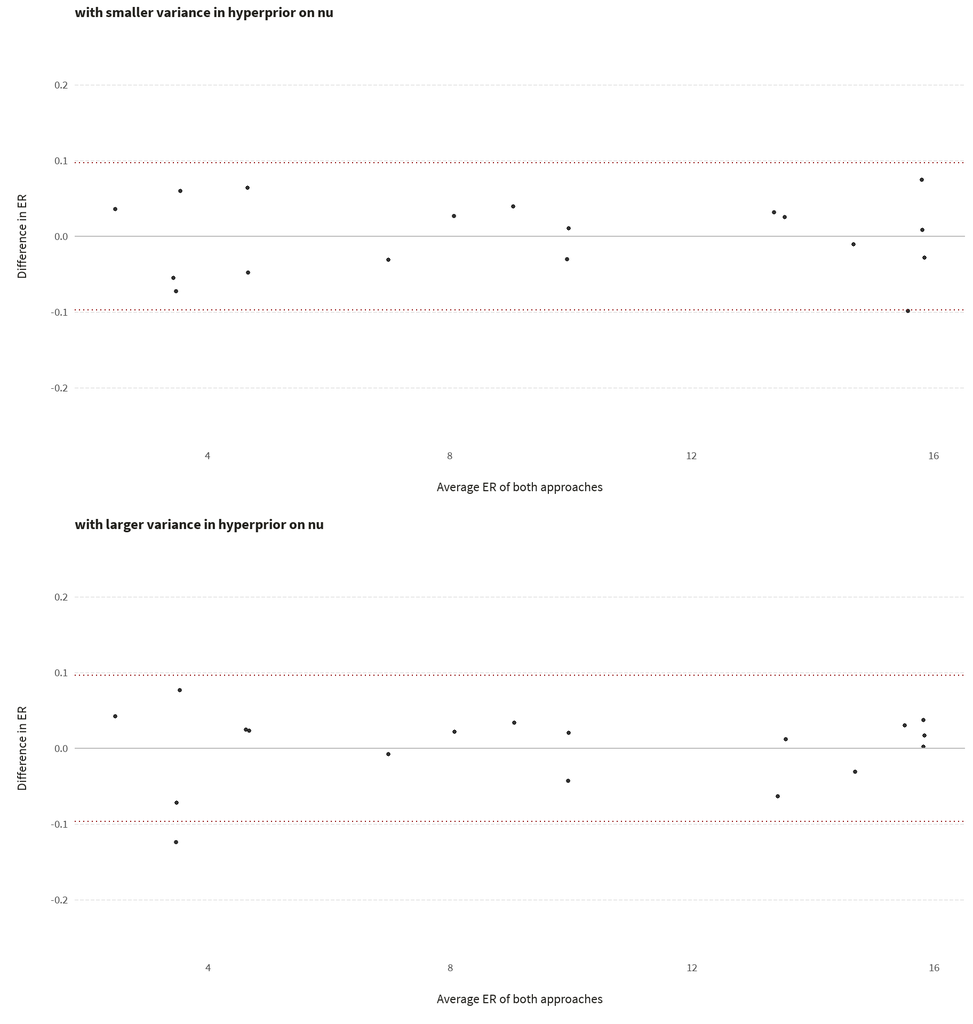

Figure 4.1: Difference in expected rank between results based on default model and a model with smaller variance (0.1<sup>2</sup>) on *ν* and another model with larger variance (2<sup>2</sup>) on *ν*. The 95% limits of agreement are plotted (red dotted lines) as well as the mean difference (gray line, bias) for the Social Science panel evaluating the Postdoc.Mobility proposals.

```r
gridExtra::grid.arrange(get_agreement_plot(ranks_hss_s$rankings,
                                           ranks_hss_s_smaller_variance$rankings,
                                           title = "with smaller variance in hyperprior on nu",
                                           ymin = -.25, ymax = .25),
                        get_agreement_plot(ranks_hss_s$rankings,
                                           ranks_hss_s_larger_variance$rankings,
                                           title = "with larger variance in hyperprior on nu",
                                           ymin = -.25, ymax = .25))
```

```r
## Use different JAGS model:
# half-cauchy on precision (https://sourceforge.net/p/mcmc-jags/discussion/610037/thread/7527c08a/)
cat("model{
      # Likelihood:
      for (i in 1:n) { # i is not the application but the review
          grade[i] ~ dnorm(mu[i], inv_sigma2)
                # inv_sigma2 is precision (1 / variance)
          mu[i] <- overall_mean + application_intercept[num_application[i]] +
          voter_intercept[num_application[i], num_voter[i]]
      }
      # Ranks:
      rank_theta[1:n_application] <- rank(-application_intercept[])
      # Priors:
      for (j in 1:n_application){
        application_intercept[j] ~ dnorm(0, inv_tau_application2)
      }
      for (l in 1:n_voter){
        for(j in 1:n_application){
          voter_intercept[j, l] ~ dnorm(nu[l], inv_tau_voter2)
        }
      }
      for (l in 1:n_voter){
        nu[l] ~ dnorm(0, 4) # 1/(0.5^2) = 4
      }
      inv_sigma2 ~ dgamma(0.01, 0.01)
      # inv_sigma2 <- pow(inv_sigma, 2)
      # inv_tau_application2 <- pow(inv_tau_application, 2)
      inv_tau_application2 ~ dgamma(0.01, 0.01)
      # inv_tau_voter2 <- pow(inv_tau_voter, 2)
      inv_tau_voter2 ~ dgamma(0.01, 0.01)
    }",
    file = here("minor_revision", "manuscript",
                "jags_model_change_halfcauchy.txt"))

##### Get the ER results: ####
# load.module("glm")
mcmc_hss_s_object_half_cauchy <-
  get_mcmc_samples(data = hss_s,
                   id_application = "proposal",
                   id_voter = "voter",
                   grade_variable = "num_grade",
                   path_to_jags_model =
                     here("minor_revision", "manuscript",
                          "jags_model_change_halfcauchy.txt"),
                   n_chains = n.chains, n_iter = n.iter,
                   n_burnin = n.burnin, n_adapt = n.adapt,
                   max_iter = max.iter,
                   inits_type = "random",
                   variables_to_sample = "specified",
                   rhat_threshold = 1.1,
                   names_variables_to_sample =
                     c("application_intercept", "inv_tau_application2",
                       "nu", "inv_tau_voter2", "rank_theta", "inv_sigma2"),
                   seed = seed + 3, quiet = TRUE, dont_bind = TRUE)


ranks_hss_s_half_cauchy <-
  get_er_from_jags(data = hss_s,
                   id_application = "proposal",
                   id_voter = "voter",
                   grade_variable = "num_grade",
                   mcmc_samples = mcmc_hss_s_object_half_cauchy)
```

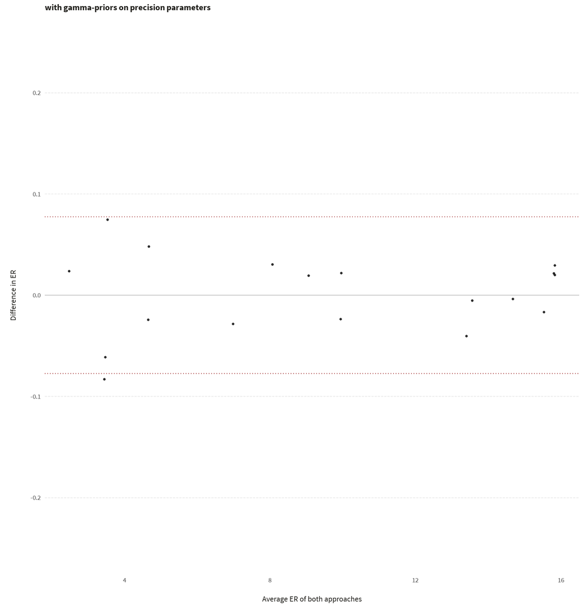

Figure 4.2: Difference in expected rank between results based on default model and a model with gamma prior on the precisions (i.e. the inverse of the variances).

```r
gridExtra::grid.arrange(get_agreement_plot(ranks_hss_s$rankings,
                                           ranks_hss_s_half_cauchy$rankings,
                                           title = "with gamma-priors on precision parameters",
                                           ymin = -.25, ymax = .25))
```